# Course8ML

# Prediction training and test sets preparation

Data frame training_df is used for model training and testing.

```r
set.seed(12345)
inTrain <- createDataPartition(training_df$classe, p=0.80, list=F)
trainDat <- training_df[inTrain, ]
testDat <- training_df[-inTrain, ]
dim(trainDat)
```

```
## [1] 15699    49
```

```r
dim(testDat)
```

```
## [1] 3923   49
```

# Modelling

“caret” train package is used with random forest classification model limited to 250 trees and variable importance evaluation.  
“train” package is run in parallel.

```r
cl <- makeCluster(detectCores())
registerDoParallel(cl)
model_rf <- train(classe ~.,data=trainDat,method="rf", importance=TRUE, ntree=250)
stopCluster(cl)
```

## Random forest model details

- Model details
- Confusion matrix
- Variables importance and plot

```r
model_rf
```

```
## Random Forest
##
## 15699 samples
##    48 predictor
##     5 classes: 'A', 'B', 'C', 'D', 'E'
##
## No pre-processing
## Resampling: Bootstrapped (25 reps)
## Summary of sample sizes: 15699, 15699, 15699, 15699, 15699, 15699, ...
## Resampling results across tuning parameters:
##
##   mtry  Accuracy   Kappa
##    2    0.9911335  0.9887805
##   25    0.9903780  0.9878240
##   48    0.9834132  0.9790096
##
## Accuracy was used to select the optimal model using the largest value.
## The final value used for the model was mtry = 2.
```

```r
rfImp <- varImp(model_rf, scale=F)
rfImp
```

```
## rf variable importance
##
##   variables are sorted by maximum importance across the classes
##   only 20 most important variables shown (out of 48)
##
##                       A     B     C     D     E
## yaw_belt          24.61 28.71 23.10 27.59 20.71
## pitch_belt        21.09 28.59 22.09 23.18 19.52
## roll_belt         22.24 25.89 27.30 27.42 21.10
## magnet_dumbbell_z 24.24 21.48 22.53 20.28 21.11
## magnet_dumbbell_y 19.38 21.84 23.94 19.91 18.80
## pitch_forearm     17.43 23.05 21.19 21.55 21.26
## accel_dumbbell_y  19.13 21.52 22.56 22.79 20.34
## roll_arm          19.36 22.61 22.17 21.49 19.63
## magnet_dumbbell_x 16.69 18.19 22.57 18.21 17.05
## yaw_arm           15.00 21.63 17.88 19.64 17.68
## accel_forearm_z   18.15 20.94 21.24 19.98 21.62
## magnet_belt_z     20.46 20.23 21.29 21.31 19.36
## gyros_arm_y       14.78 21.28 19.45 18.71 17.96
## accel_dumbbell_z  17.51 21.01 21.11 19.53 18.52
## gyros_dumbbell_y  16.59 19.83 20.90 17.58 16.09
## gyros_belt_z      17.45 20.82 17.02 18.23 19.63
## roll_dumbbell     15.46 17.98 20.67 17.95 17.23
## magnet_forearm_z  17.22 20.49 19.43 18.65 20.46
## magnet_belt_y     18.47 20.26 19.72 19.06 19.41
## gyros_dumbbell_z  14.87 19.77 17.61 17.46 17.24
```

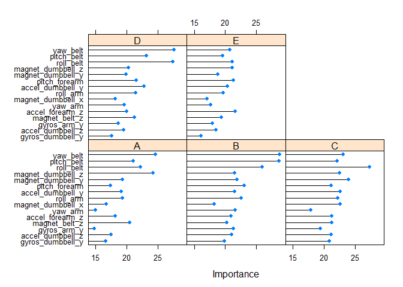

```r
plot(rfImp,top=15)
```

## Testing model accuracy

- Confusion matrix predictions vs test data
- Model accuracy is above 99%

```r
pred_rf <- predict(model_rf, testDat)
confusionMatrix(pred_rf, testDat$classe)
```

```
## Confusion Matrix and Statistics
##
##           Reference
## Prediction    A    B    C    D    E
##          A 1116    5    0    0    0
##          B    0  753    9    0    0
##          C    0    1  675   13    0
##          D    0    0    0  630    2
##          E    0    0    0    0  719
##
## Overall Statistics
##
##                Accuracy : 0.9924
##                  95% CI : (0.9891, 0.9948)
##     No Information Rate : 0.2845
##     P-Value [Acc > NIR] : < 2.2e-16
##
##                   Kappa : 0.9903
##  Mcnemar's Test P-Value : NA
##
## Statistics by Class:
##
##                      Class: A Class: B Class: C Class: D Class: E
## Sensitivity            1.0000   0.9921   0.9868   0.9798   0.9972
## Specificity            0.9982   0.9972   0.9957   0.9994   1.0000
## Pos Pred Value         0.9955   0.9882   0.9797   0.9968   1.0000
## Neg Pred Value         1.0000   0.9981   0.9972   0.9960   0.9994
## Prevalence             0.2845   0.1935   0.1744   0.1639   0.1838
## Detection Rate         0.2845   0.1919   0.1721   0.1606   0.1833
## Detection Prevalence   0.2858   0.1942   0.1756   0.1611   0.1833
## Balanced Accuracy      0.9991   0.9946   0.9913   0.9896   0.9986
```

```r
confusionMatrix(pred_rf, testDat$classe)$overall[1]
```

```
##  Accuracy
## 0.9923528
```

# Application to test cases

The random forest model evaluated in “Testing model accuracy” is applied to the 20 test cases.  
Test cases predicted Classes are listed.

```r
dim(testcases_df)
```

```
## [1] 20 48
```

```r
pred_20 <- predict(model_rf, testcases_df)
pred_20
```

```
##  [1] B A B A A E D B A A B C B A E E A B B B
## Levels: A B C D E
```